*Draft! Prepared 2021-10-13 using country-reported data CSV files dated 2021-09-13 and estimates files dated 2021-08-16.*

### Fig. 3.4.1 The global number of people reported to have been enrolled on treatment for MDR/RR-TB, 2015–2020

Global data disaggregated by age are not available for the years before 2018

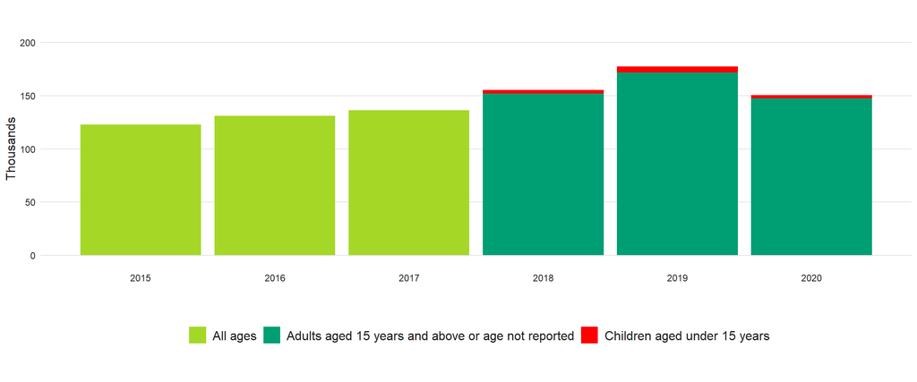

### Fig. 3.4.2 Number of MDR/RR-TB cases detected (blue) and enrolled on MDR-TB treatment (red), 2010−2020, 30 high MDR-TB burden countries

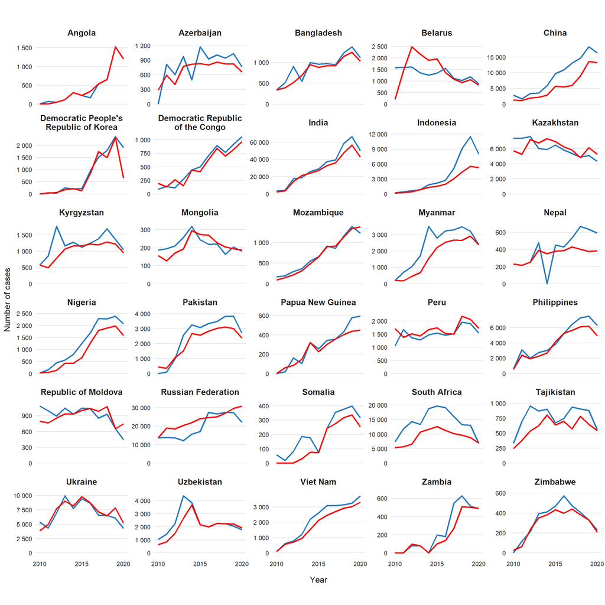

### Fig. 3.4.3 Global progress in the number of people treated for MDR/RR-TB between 2018 and 2020, compared with cumulative targets set for 2018–2022 at the UN high-level meeting on TB

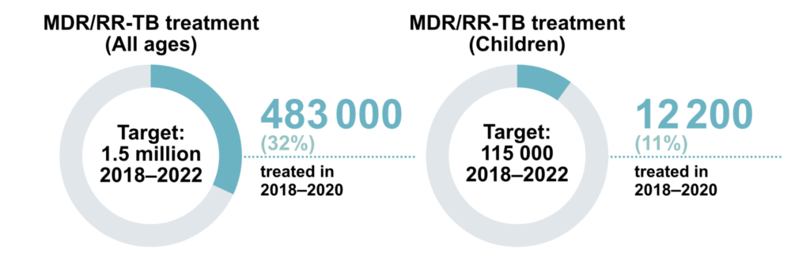

### Fig. 3.4.4 Treatment outcomes for MDR/RR-TB cases globally 2012−2018

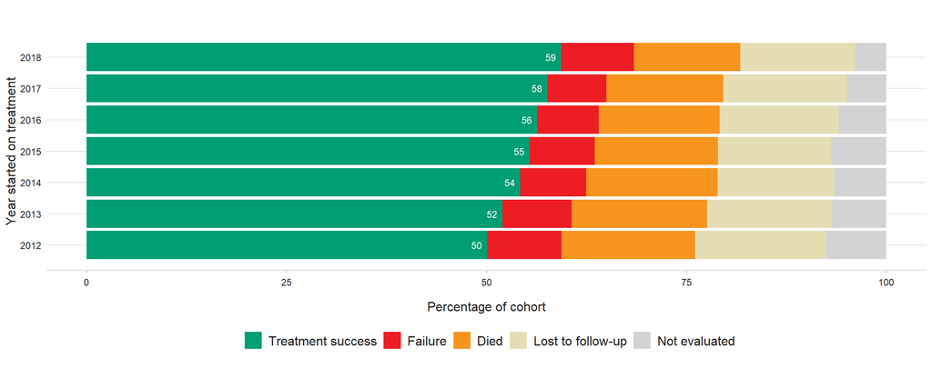

### Fig. 3.4.5 Treatment outcomes for MDR/RR-TB cases started on treatment in 2018, WHO regions and globally

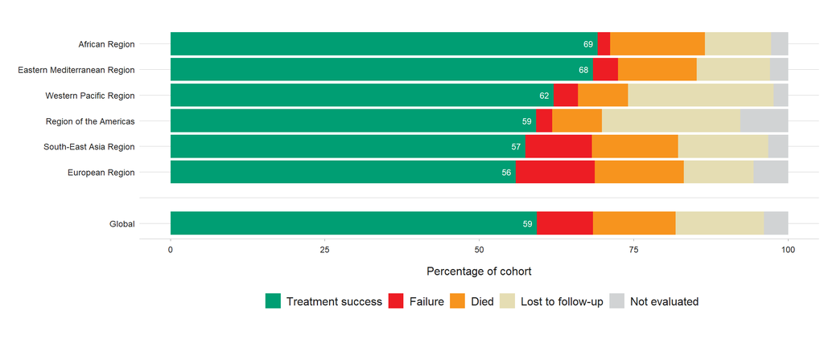

### Fig. 3.4.6 Countries that used bedaquiline for the treatment of MDR/XDR-TB as part of expanded access, compassionate use or under normal programmatic conditions by the end of 2020

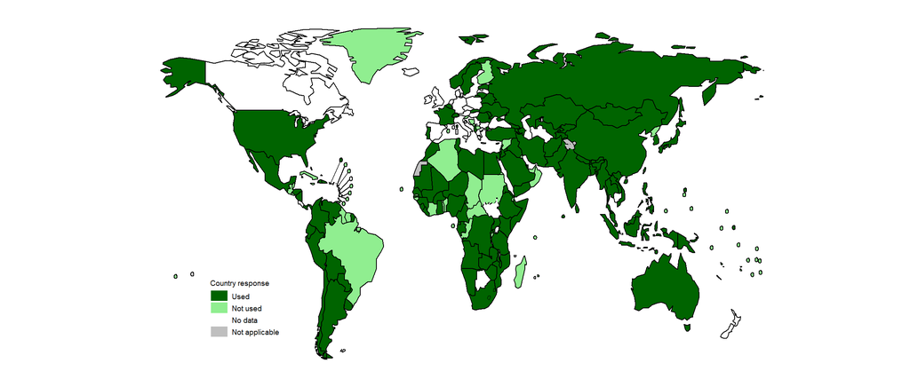

### Fig. 3.4.7 Countries that used all-oral longer MDR-TB treatment regimens by the end of 2020

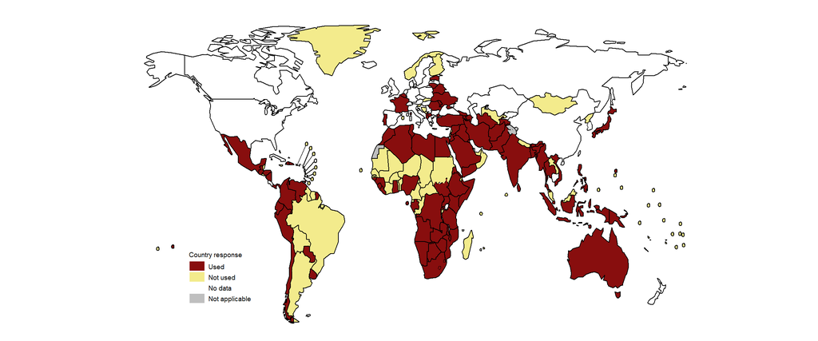

### Fig. 3.4.8 Countries that used all-oral shorter MDR-TB treatment regimens by the end of 2020

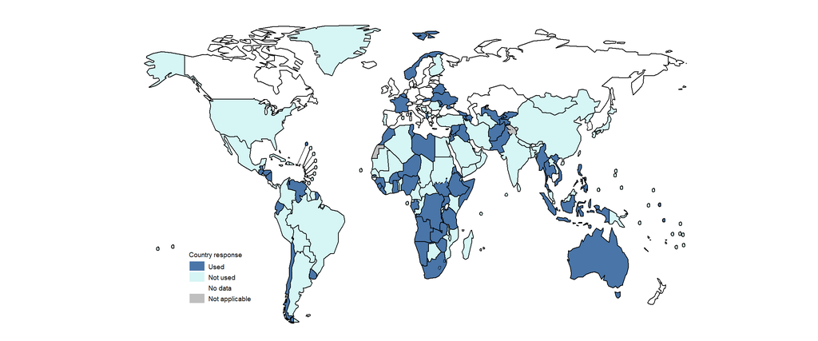

### Fig. 3.4.9 Number of patients with active follow up of adverse events as a proportion of patients enrolled on treatment for drug-resistant TB, 2020

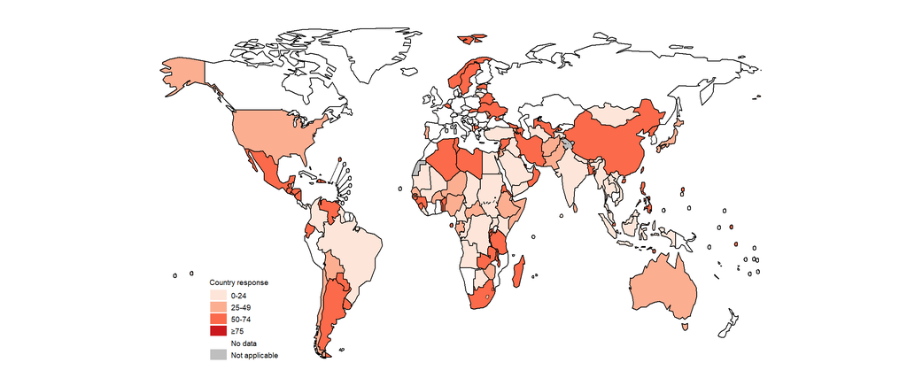